# Visualizations LDA coefficients

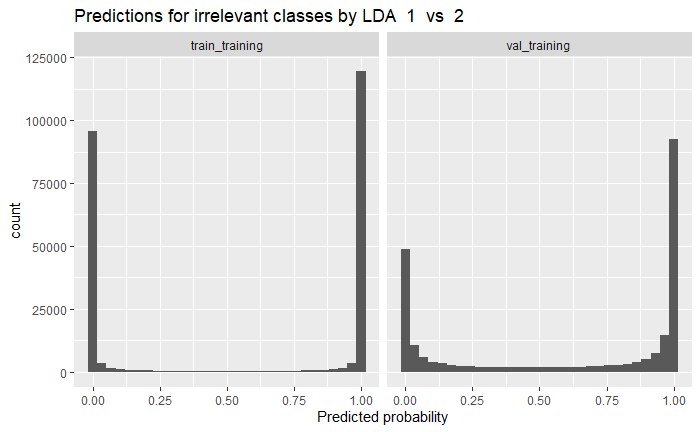

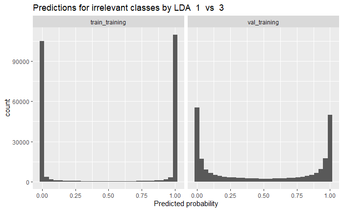

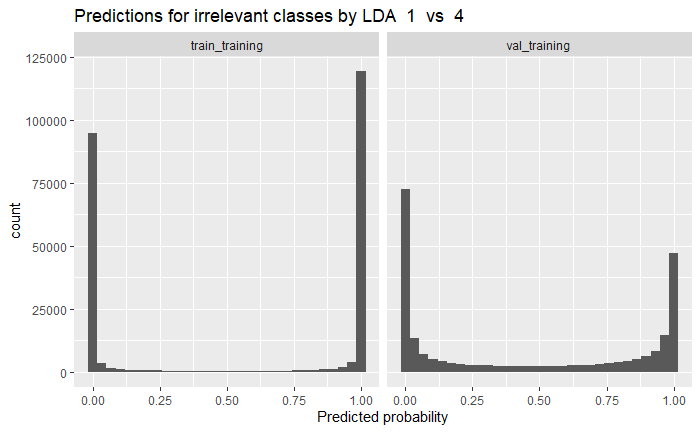

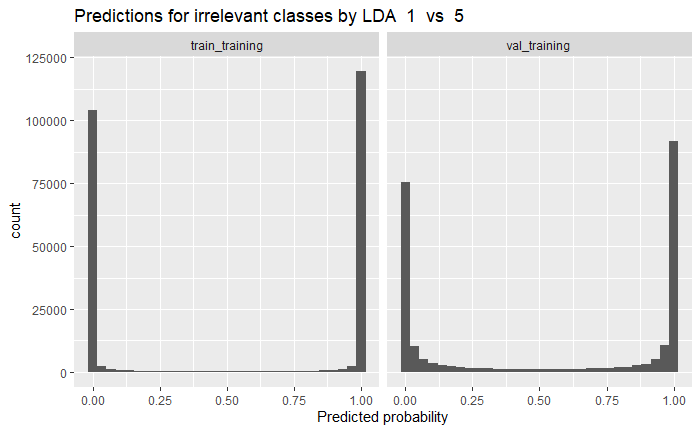

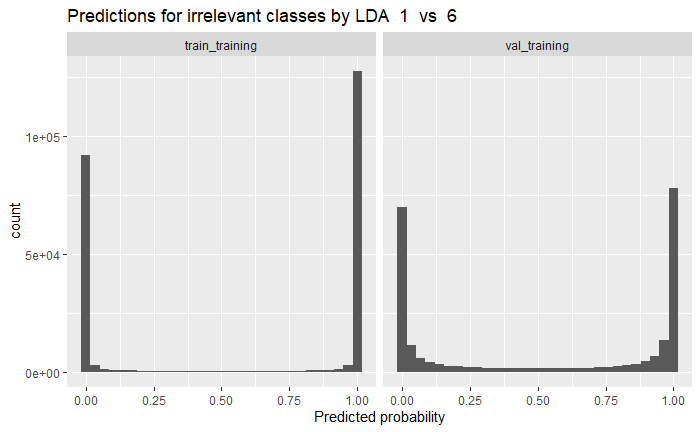

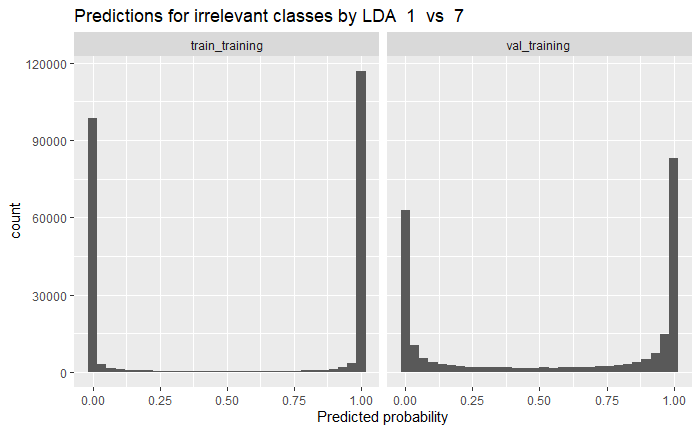

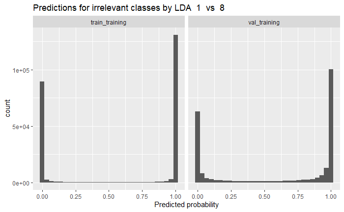

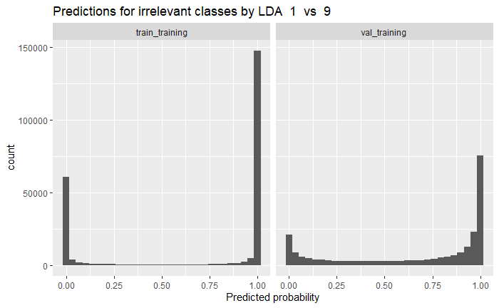

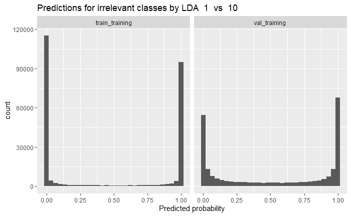

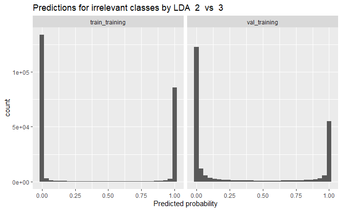

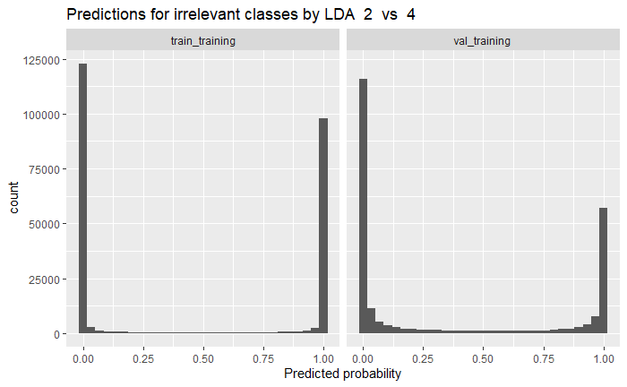

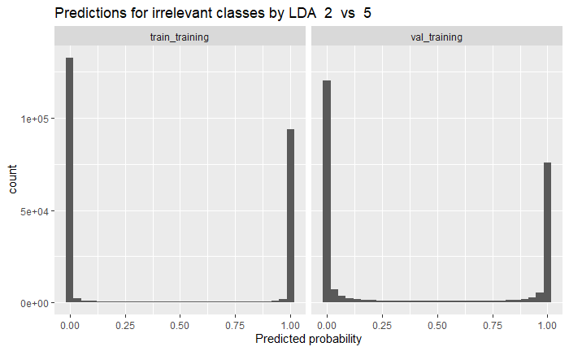

[33 more figures not shown]

```r
for (cl1 in 1:(classes - 1))
{
  for (cl2 in (cl1 + 1):classes)
  {
    irrel_plt <- ens_pw_irrel %>% filter(class1 == (cl1 - 1) & class2 == (cl2 - 1)) %>% ggplot() +
      geom_histogram(mapping=aes(x=pred1), bins=30) + facet_wrap(~train_set) +
      ggtitle(paste("Predictions for irrelevant classes by LDA ", cl1, " vs ", cl2)) +
      xlab("Predicted probability")

    print(irrel_plt)
  }
}
```

These histograms show, that even for unknown classes, LDA most osten produces probabilities close to one and zero. One exception is val_train LDA for class pair 4 and 6, where probabilities are divided evenly. Also the confidence plot for this LDA looks sensibly.

## CIFAR 10 half

```r
base_dir <- "../data/data_train_val_half_c10"
repls <- 0:0
folds <- 0:49
classes <- 10
lda_coefs <- load_lda_coefs(base_dir, repls, folds)
net_pw_results <- read.csv(file.path(base_dir, "net_pw_accuracies.csv"))
ens_pw_results <- read.csv(file.path(base_dir, "ensemble_pw_accuracies.csv"))
net_pw_results[, c("class1", "class2")] <- lapply(net_pw_results[, c("class1", "class2")], as.factor)
ens_pw_results[, c("class1", "class2")] <- lapply(ens_pw_results[, c("class1", "class2")], as.factor)
```

```r
for (cl1 in 1:(classes - 1))
{
  for (cl2 in (cl1 + 1):classes)
  {
    lda_plt <- lda_coefs %>% filter(class1 == cl1 & class2 == cl2) %>% ggplot() + geom_boxplot(aes(x=coefficient, y=value)) +
      facet_wrap(~train_type) + ggtitle("LDA coefficients")
    acc_plt_net <- net_pw_results %>% filter(class1 == (cl1 - 1) & class2 == (cl2 - 1)) %>% ggplot(mapping=aes(x=network, y=accuracy)) +
      geom_boxplot() + ggtitle("Pairwise accuracies of networks")
    acc_plt_ens <- ens_pw_results %>% filter(class1 == (cl1 - 1) & class2 == (cl2 - 1)) %>% ggplot(mapping=aes(y=accuracy)) +
      geom_boxplot() + facet_wrap(~train_set) + ggtitle("Pairwise accuracies of LDA output") +
      theme(axis.ticks.x=element_blank(), axis.text.x=element_blank())


    print((acc_plt_net/lda_plt/acc_plt_ens) + plot_annotation(title=paste("Classes ", cl1, " vs ", cl2)))
  }
}
```

[output not shown]

## CIFAR 100 half

```r
base_dir <- "../data/data_train_val_half_c100"
repls <- 0:9
folds <- 0:4
classes <- 10
lda_coefs <- load_lda_coefs(base_dir, repls, folds)
net_pw_results <- read.csv(file.path(base_dir, "net_pw_accuracies.csv"))
ens_pw_results <- read.csv(file.path(base_dir, "ensemble_pw_accuracies.csv"))
net_pw_results[, c("class1", "class2")] <- lapply(net_pw_results[, c("class1", "class2")], as.factor)
ens_pw_results[, c("class1", "class2")] <- lapply(ens_pw_results[, c("class1", "class2")], as.factor)
```

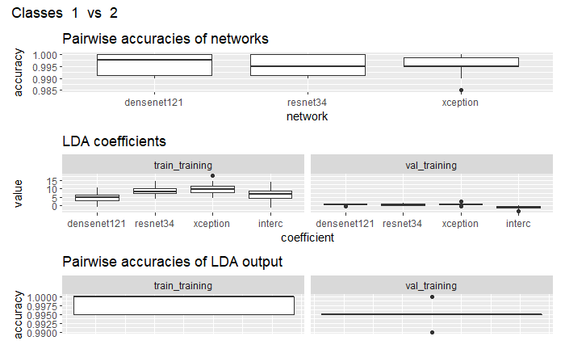

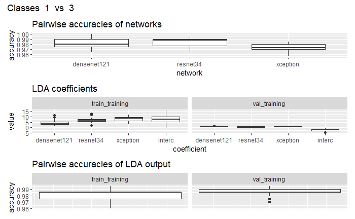

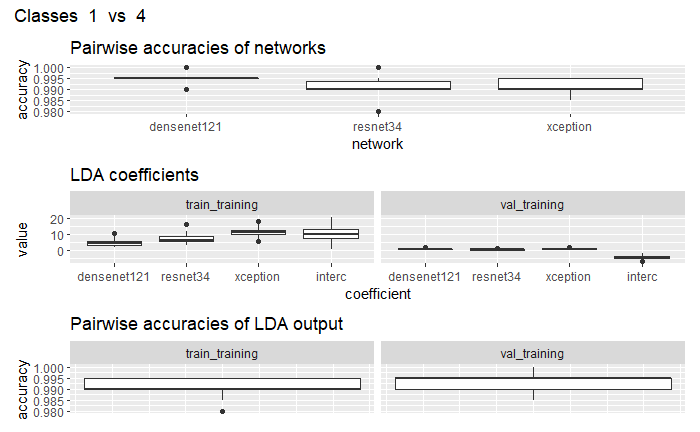

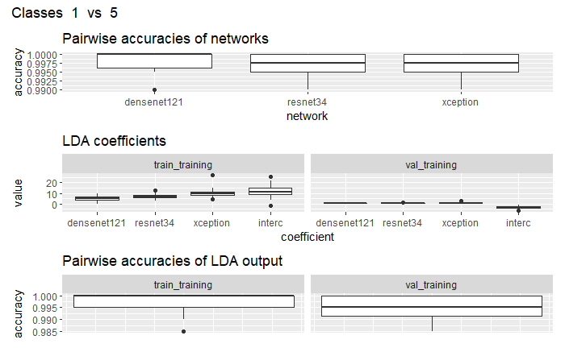

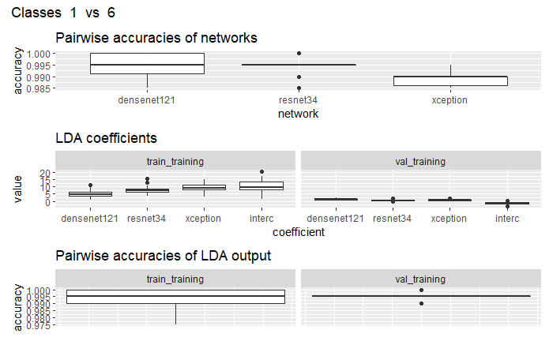

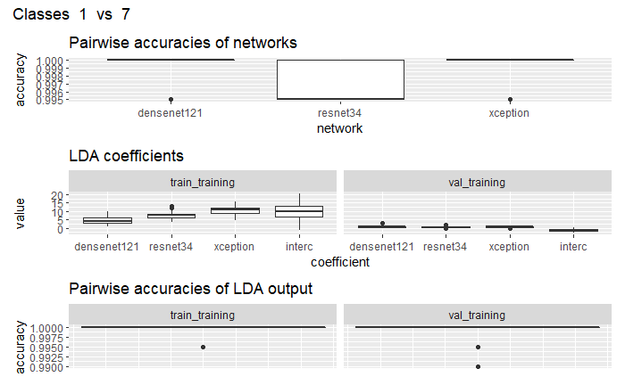

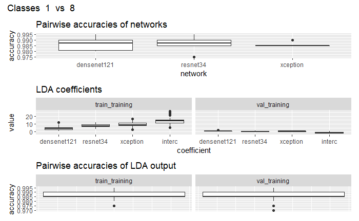

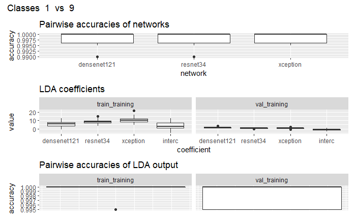

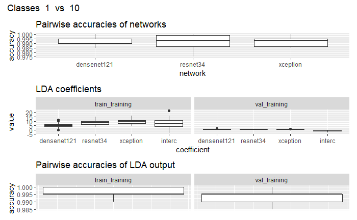

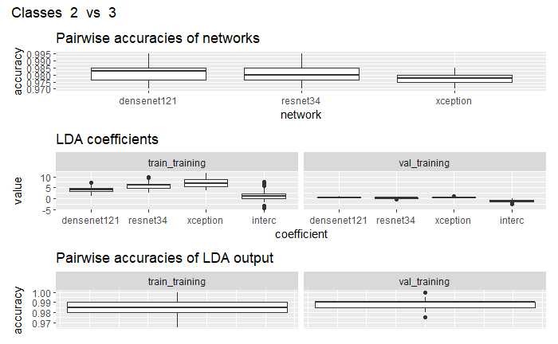

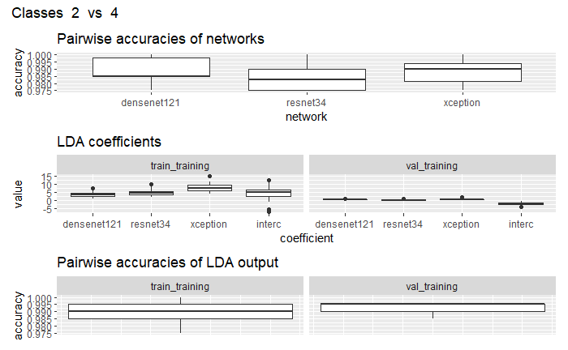

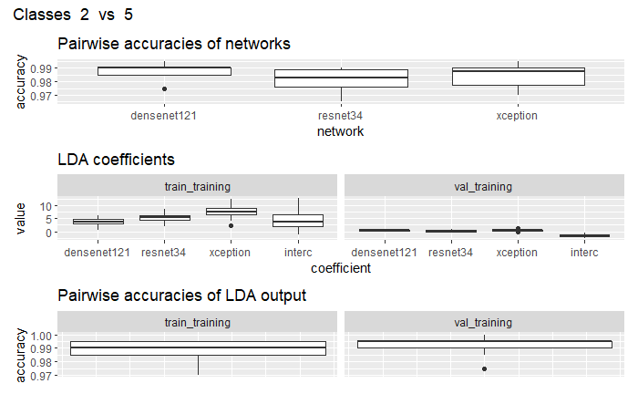

[33 more figures not shown]

```r
for (cl1 in 1:(classes - 1))
{
  for (cl2 in (cl1 + 1):classes)
  {
    lda_plt <- lda_coefs %>% filter(class1 == cl1 & class2 == cl2) %>% ggplot() + geom_boxplot(aes(x=coefficient, y=value)) +
      facet_wrap(~train_type) + ggtitle("LDA coefficients")
    acc_plt_net <- net_pw_results %>% filter(class1 == (cl1 - 1) & class2 == (cl2 - 1)) %>% ggplot(mapping=aes(x=network, y=accuracy)) +
      geom_boxplot() + ggtitle("Pairwise accuracies of networks")
    acc_plt_ens <- ens_pw_results %>% filter(class1 == (cl1 - 1) & class2 == (cl2 - 1)) %>% ggplot(mapping=aes(y=accuracy)) +
      geom_boxplot() + facet_wrap(~train_set) + ggtitle("Pairwise accuracies of LDA output") +
      theme(axis.ticks.x=element_blank(), axis.text.x=element_blank())


    print((acc_plt_net/lda_plt/acc_plt_ens) + plot_annotation(title=paste("Classes ", cl1, " vs ", cl2)))
  }
}
```

Here are too many class pair combinations to draw them all. TODO: think of some criteria to draw interesting ones.